# Internet Speedtest DOE

Melky Simorangkir

6/10/2021

# Assumptions for ANOVA Testing

The assumption of Anova are:

- Samples are independent from one another (within and among groups).
- Samples were randomly chosen.
- Response variable is normally distributed
- Variances are equal among groups.

# Data Preparation

1. Provider (3 level)
- p1 : XL
- p2 : INDOSAT
- p3 : TELKOMSEL
2. Location (2 Level)
- l1 : Perumahan
- l2 : Perkantoran
3. Time (2 Level)
- t1 : Working Hour
- t2 : Non Working Hour

Pada pengambilan data kecepatan unduh layanan internet, beberapa batasan yang dilakukan untuk penyamaan perlakuan yaitu:

1. Perangkat selular yang digunakan memiliki kemampuan yang sama dalam mengakses layanan internet.
2. Pengujian dilakukan tidak pada suatu ketinggian tertentu seperti pada lantai gedung yang tinggi.
3. Paket internet yang digunakan merupakan paket internet berbasis kuota yang dimana tidak ada pengaruh terhadap *Fair Usage Policy* (FUP)

## Import dataset

```
##    Provider Location Time Speed
## 1        p1       l1   t1  11.6
## 2        p2       l1   t1  11.4
## 3        p3       l1   t1  11.7
## 4        p1       l1   t2   8.8
## 5        p2       l1   t2  12.8
## 6        p3       l1   t2   7.7
## 7        p1       l2   t1  34.9
## 8        p2       l2   t1  10.5
## 9        p3       l2   t1  25.0
## 10       p1       l2   t2  32.6
## 11       p2       l2   t2  11.4
## 12       p3       l2   t2  21.9
## 13       p1       l1   t1  12.4
## 14       p2       l1   t1  12.4
```

[output cut: 22 more lines]

# Data Analysis

## Interaction Plotting

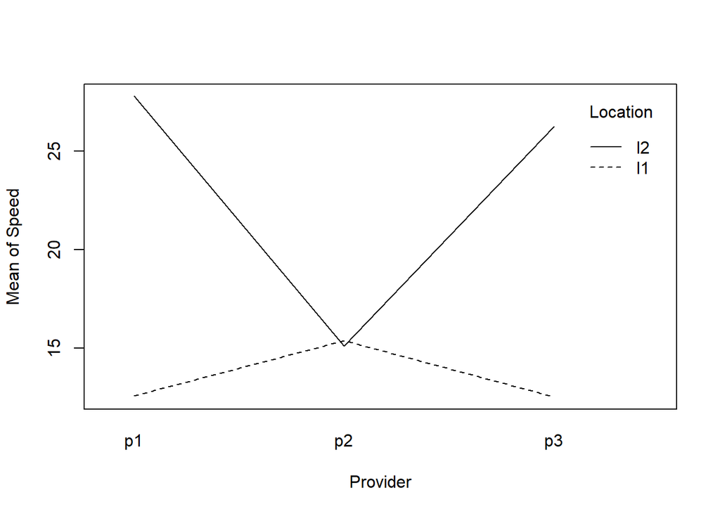

Berikut merupakan interaksi rataan untuk *Factor A* terhadap rata - rata kecepatan layanan internet

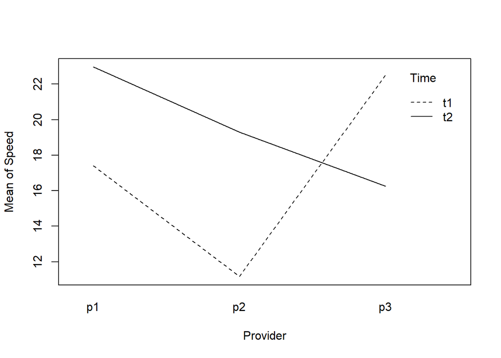

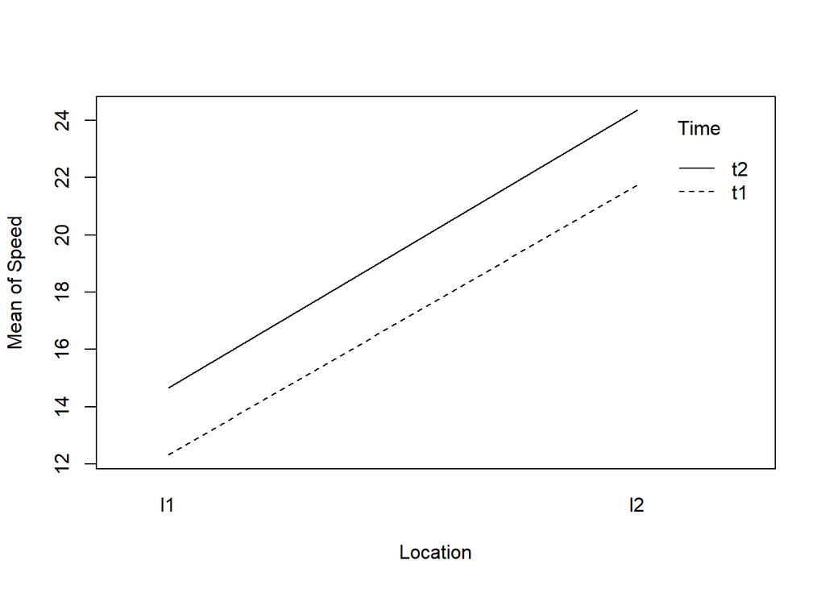

## Dataset Plotting

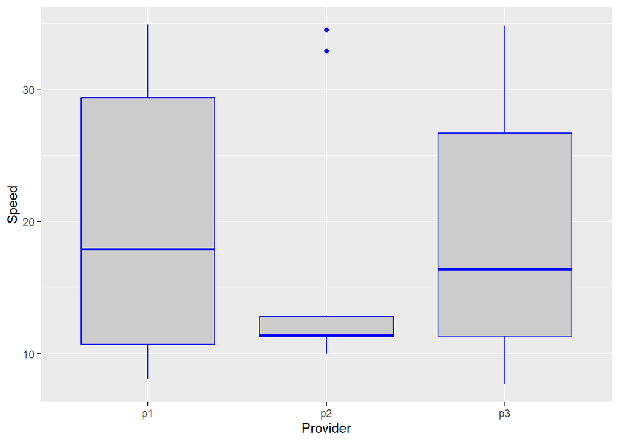

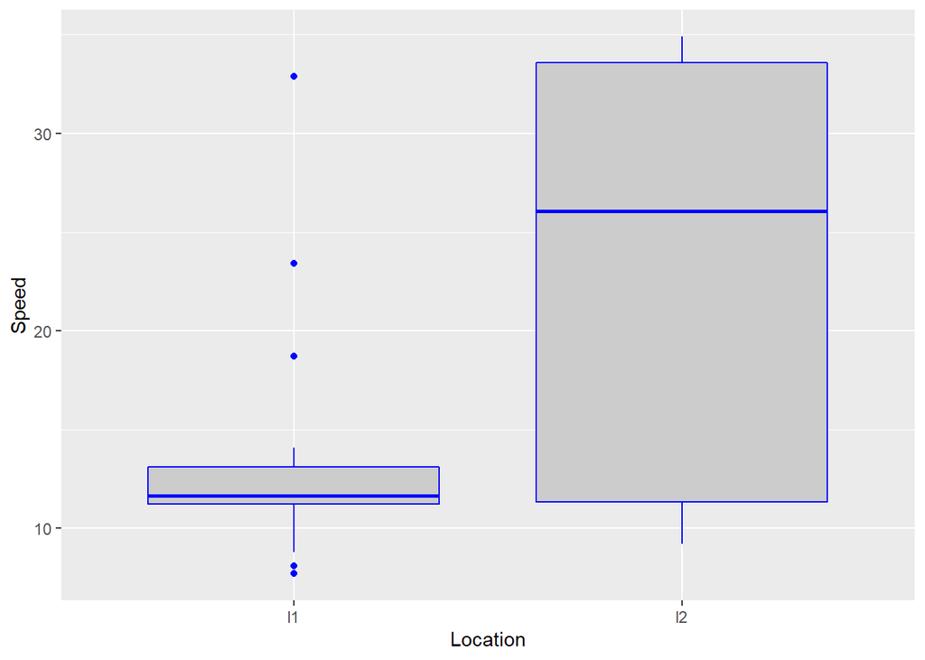

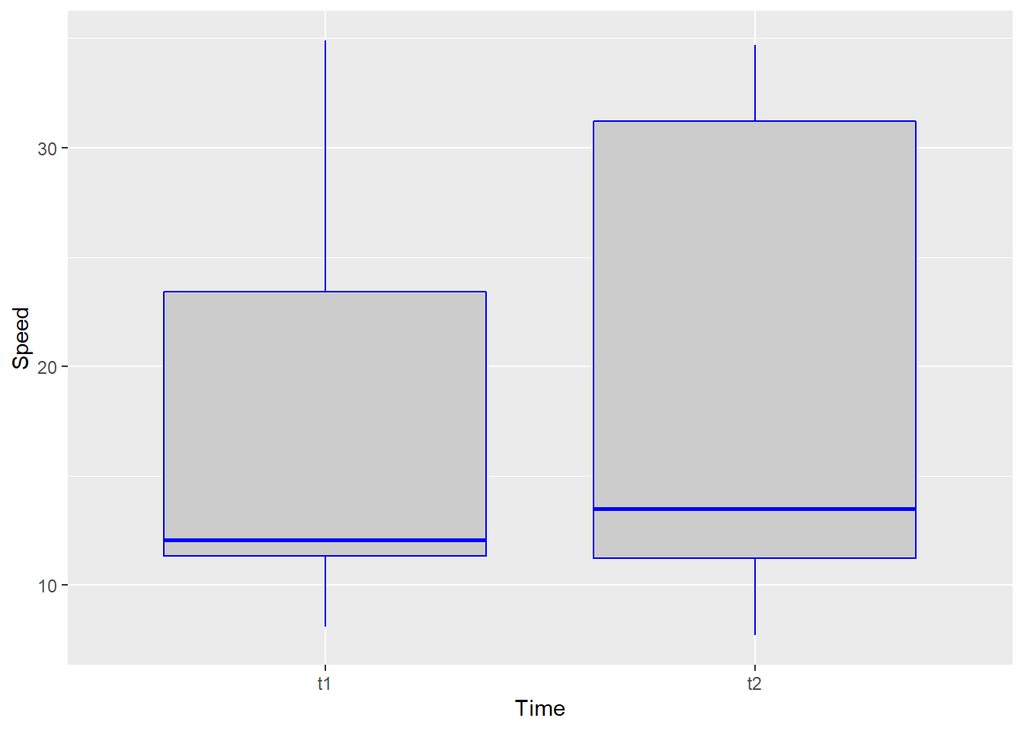

## Homogenity of Variance Testing

```
## # A tibble: 1 x 4
##     df1   df2 statistic     p
##   <int> <int>     <dbl> <dbl>
## 1    11    24     0.685 0.739
```

Jadi nilai levene test untuk menguji homogenitas variansi adalah 0.7393164 dimana angka ini > 0.05 sehingga dapat dikatakan bahwa data yang digunakan bersifat homogen pada setiap grup.

## Normality testing

```
##
##  Shapiro-Wilk normality test
##
## data:  residuals(lm(Speed ~ ., data = speed.df))
## W = 0.98101, p-value = 0.7789
```

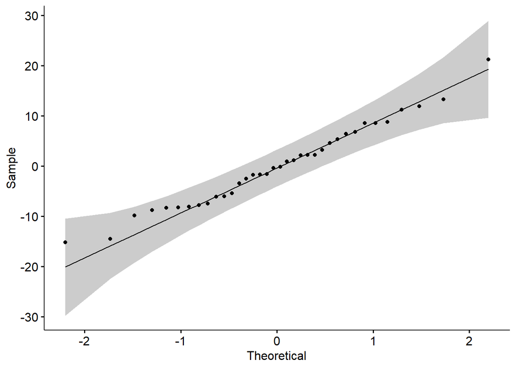

Terlihat pada hasil plot data, persebaran data tidak menunjukkan adanya data yang berada jauh atau berbeda secara signifikan sehingga data yang digunakan ini dapat dikatakan berdistribusi secara normal dan dapat digunakan untuk memenuhi asumsi kenormalan.

# Analysis of Variance (ANOVA) 3 Factors

```
## Analysis of Variance Table
##
## Response: dependent.var
##                      Df  Sum Sq Mean Sq F value  Pr(>F)
## fact.A                2  169.84   84.92  1.3353 0.28194
## fact.B                1  822.73  822.73 12.9361 0.00145 **
## fact.C                1   55.01   55.01  0.8649 0.36163
## fact.A:fact.B         2  437.93  218.97  3.4429 0.04847 *
## fact.A:fact.C         2  353.67  176.83  2.7804 0.08202 .
## fact.B:fact.C         1    0.17    0.17  0.0027 0.95876
## fact.A:fact.B:fact.C  2   26.58   13.29  0.2090 0.81286
## Residuals            24 1526.39   63.60
## ---
## Signif. codes:  0 '***' 0.001 '**' 0.01 '*' 0.05 '.' 0.1 ' ' 1
```

Setelah melakukan pengujian dengan menggunakan Analysis of Variance (ANOVA) dengan 3 faktor, hasil dapat dilihat dengan adanya perbedaan rataan yang signifikan pada Faktor B (Lokasi) dan interaksi antara Faktor A dan Faktor B dengan *p-value* < 0.05. Perbedaan rataan pada interaksi Faktor A dan B signifikansi berada pada rentang 0.01 - 0.05 dimana apabila taraf signikansi berada pada 0.01 maka interaksi Faktor A dan B menjadi tidak signifikan.

## Model Plotting

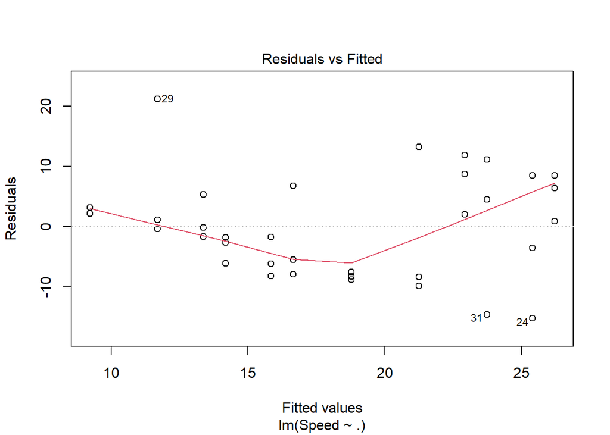

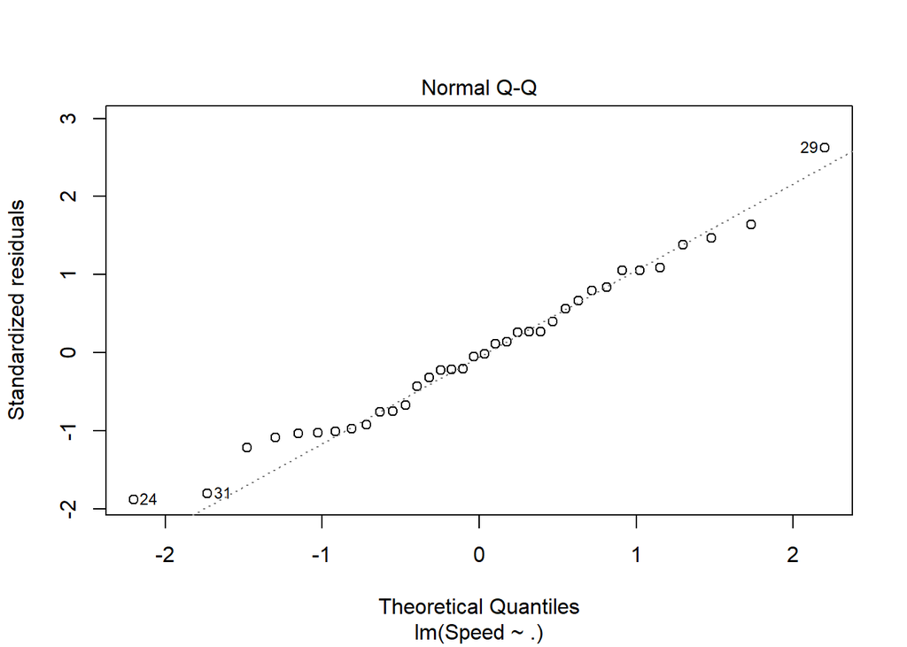

# Post Hoc Analysis - LSD

Setelah melakukan pengujian dengan menggunakan metode ANOVA ditemukan beberapa faktor yang mempengaruhi kecepatan unduh dari layanan internet, sehingga untuk lebih jelas dalam melihat perbedaan rataan yang mempengaruhinya dilakukan analisa lebih lanjut (Post Hoc Analysis) dengan menggunakan metode *Fisher Least Significant Difference* atau lebih dikenal dengan LSD.

Pengujian LSD dilakukan pada Faktor B (Location) dan Faktor interaksi A dan B (Interaksi antara *Provider* dan *Location*), berikut adalah hasil dari pengujian LSD:

```
## [1] "The means of levels of factor B are not same, so go for multiple comparison test"
```

```
## [[1]]
##    MSerror Df     Mean       CV  t.value      LSD
##   63.59972 24 18.26944 43.65181 2.063899 5.486491
##
## [[2]]
##    dependent.var groups
## l2      23.05000      a
## l1      13.48889      b
```

Dapat dilihat dari hasil bahwa ada perbedaan signifikan rataan antara lokasi perkantoran ($l_2$) dan perumahan ($l_1$) berturut - turut sebesar 23.05 dan 13.4889, dengan hasil uji tersebut dapat diindikasikan bahwa pemilihan lokasi (dalam hal ini perumahan dan perkantoran) pada saat menggunakan layanan internet dapat meningkatkan kecepatan unduh layanan internet saat digunakan. Selain itu, hal ini mengindikasikan bahwa traffic layanan yang terjadi di perumahaan pada masa pandemi ini lebih besar dibandingkan dengan layanan yang terjadi di perkantoran.

Untuk diskusi dan penelitian lebih lanjut dapat disarankan untuk melihat apakah benar ada pengaruh yang terjadi pada traffic layanan yang disebabkan oleh aktifitas *work from home*.

```
## [1] "The means of levels of interaction between A and B factors are not same, so go for multiple comparison test"
```

```
## [[1]]
##    MSerror Df     Mean       CV  t.value      LSD
##   63.59972 24 18.26944 43.65181 2.063899 9.502882
##
## [[2]]
##       dependent.var groups
## p1:l2      27.80000      a
## p3:l2      26.25000      a
## p2:l1      15.36667      b
## p2:l2      15.10000      b
## p1:l1      12.58333      b
## p3:l1      12.51667      b
```

Untuk pengujian LSD yang kedua, yaitu adanya perbedaan rataan dari interaksi faktor A ( *Provider* ) dan faktor B ( *Location*) yang mempengaruhi kecepatan unduh layanan internet dimana Provider XL ($p_1$) dan Provider Telkomsel ($p_3$) pada lokasi perkantoran ($l_2$) memiliki perbedaan rataan yang lebih besar dibandingkan kombinasi interaksi faktor *Provider* dan *Location* lainnya. Dengan hal ini dapat diindikasikan bahwa pemilihan *Provider* dan *Location* yang tepat dapat meningkatkan kecepatan unduh layanan internet berbasis kuota.

## Kesimpulan

Dengan adanya pengujian pengaruh faktor *Provider*, *Location* dan *Time* diatas dapat disimpulkan bahwa:

1. *Provider* yang memberikan layanan internet berbasis kuota yaitu XL, INDOSAT dan TELKOMSEL tidak memiliki perbedaan performansi dalam memberikan kecepatan layanan internet ke pelanggan.
2. *Location* terindikasi mempengaruhi kecepatan unduh layanan internet dimana lokasi perkantoran memiliki performansi lebih baik dibandingkan lokasi perumahan. Hal ini juga bisa berindikasi terhadap adanya aktifitas *work from home* pada masa pandemi.
3. *Time* terindikasi tidak mempengaruhi kecepatan unduh layanan internet. Indikasi ini dapat didiskusikan lebih lanjut dengan melihat apakah penggunaan layanan saat masa pandemi mengalami pergeseran dimana penggunaan layanan internet pada masa pandemi secara menyeluruh tidak dipengaruhi waktu.
4. Adanya pengaruh interaksi Faktor A dan B yaitu *Provider* dan *Location* terhadap Kecepatan unduh layanan internet dimana XL dan Telkomsel pada lokasi perkantoran memiliki performansi yang lebih baik daripada interaksi faktor *Provider* dan *Location* lainnya.